# ECO 602 Final Project

## Functions 2: Numerical Data Exploration

### `summary()`

The function `summary()` produces the summary statistics of various objects (e.g. vectors, matrices, data frames) or model fitting functions.

Here’s an example with a basic object:

```r
# For a vector, this summary includes minimum, mean, maximum, and quartile values.

summary(c(1:15))
```

```
##    Min. 1st Qu.  Median    Mean 3rd Qu.    Max.
##     1.0     4.5     8.0     8.0    11.5    15.0
```

```r
# For an object with multiple lists or columns, a summary table will print for each list or column.

summary(ethereal)
```

```
##        V1             V2             V3             V4
##  Min.   : 6.0   Min.   :25.0   Min.   :44.0   Min.   :63.0
##  1st Qu.:10.5   1st Qu.:29.5   1st Qu.:48.5   1st Qu.:67.5
##  Median :15.0   Median :34.0   Median :53.0   Median :72.0
##  Mean   :15.0   Mean   :34.0   Mean   :53.0   Mean   :72.0
##  3rd Qu.:19.5   3rd Qu.:38.5   3rd Qu.:57.5   3rd Qu.:76.5
##  Max.   :24.0   Max.   :43.0   Max.   :62.0   Max.   :81.0
```

Here’s an example with a linear model fit:

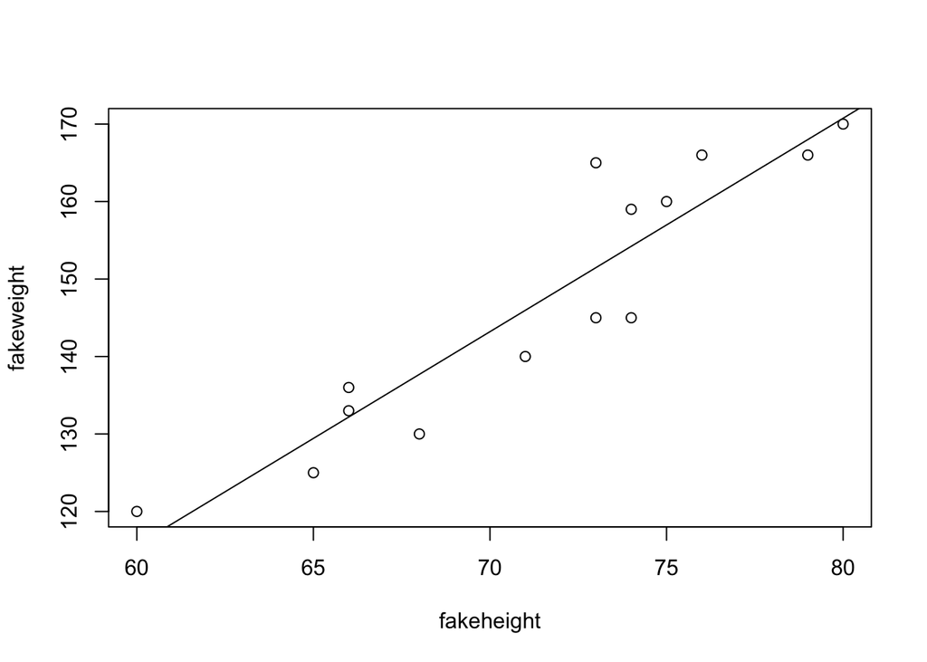

```r
# We can use also use summary() to examine the results of models, such as a simple linear model.

# First, we can create a data frame containing mock heights and weights of an unknown population.

proportional <- data.frame(
  fakeheight = c(60, 65, 66, 68, 66, 71, 73, 74, 74, 75, 73, 76, 79, 80),
  fakeweight = c(120, 125, 136, 130, 133, 140, 145, 145, 159, 160, 165, 166, 166, 170))

# We can then fit a linear model to describe the relationship between height on the x and weight on the y.

cant.relate <- lm(fakeweight ~ fakeheight, data = proportional)

# Let's plot our data and add the linear model for the sake of data visualization and improved understanding.

plot(fakeweight ~ fakeheight, data = proportional)
abline(cant.relate)
```

```r
# Now we'll use summary() to examine the results of the model.

summary(cant.relate)
```

```
##
## Call:
## lm(formula = fakeweight ~ fakeheight, data = proportional)
##
## Residuals:
##     Min      1Q  Median      3Q     Max
## -9.2277 -5.5792  0.0275  4.2124 13.5275
##
## Coefficients:
##             Estimate Std. Error t value Pr(>|t|)
## (Intercept) -49.6575    23.1749  -2.143   0.0533 .
## fakeheight    2.7552     0.3235   8.517 1.97e-06 ***
## ---
## Signif. codes:  0 '***' 0.001 '**' 0.01 '*' 0.05 '.' 0.1 ' ' 1
##
## Residual standard error: 6.672 on 12 degrees of freedom
## Multiple R-squared:  0.8581, Adjusted R-squared:  0.8462
## F-statistic: 72.54 on 1 and 12 DF,  p-value: 1.969e-06
```

```r
# y-intercept = -49.6575
# slope = 2.7552
# p-value = 1.97e-06
# nice!
```

### `mean()`

The function `mean()` returns the arithmetic mean of the values in an R object.

- Acceptable objects include numeric/logical vectors, date, date-time, and time interval objects.
- By default, mean() will return a NULL if NA values are included in the dataset. na.rm = TRUE can be used to ignore NA values.

```r
mean(ethereal)
```

```
## [1] 43.5
```

### `sd()`

The function `sd()` returns the standard deviation of the values in an R object.

- By default, sd() will return a NULL if NA values are included in the dataset. na.rm = TRUE can be used to ignore NA values.

```r
sd(ethereal)
```

```
## [1] 22.08318
```

## Functions 3: Graphical Data Exploration

### `par()`

The function `par()` is used to set graphical parameters.

A common application is the creation of multiple “panels,” or a matrix of graphical displays.

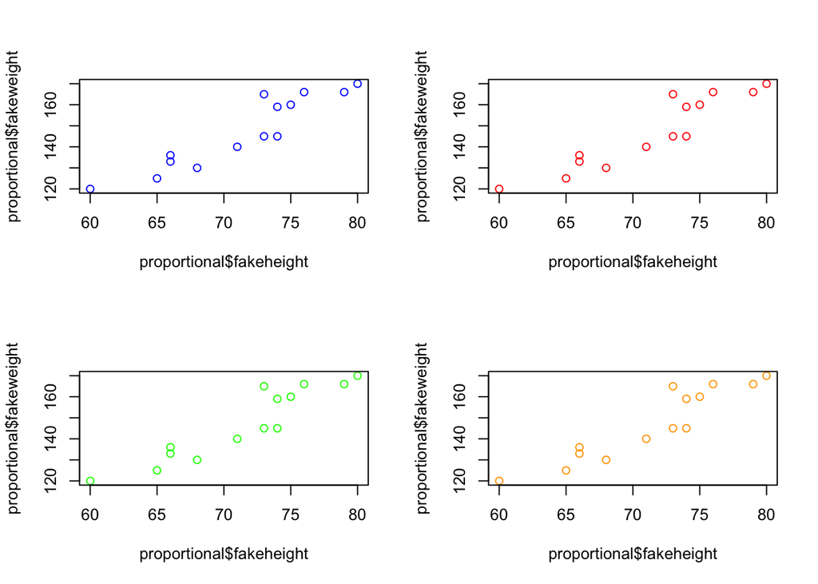

```r
# The mfrow argument sets the dimensions of the graphical matrix. Here we will create a "blank canvas" of size 2 x 2 which will hold the next four plots we create.
par(mfrow = c(2,2))

plot(proportional$fakeheight, proportional$fakeweight, col = "blue")
plot(proportional$fakeheight, proportional$fakeweight, col = "red")
plot(proportional$fakeheight, proportional$fakeweight, col = "green")
plot(proportional$fakeheight, proportional$fakeweight, col = "orange")
```

```r
# dev.off() can be used to reset graphical parameters.

dev.off()
```

```r
# All clear!
```

### `plot()`

I can use `plot()` to create scatterplots.

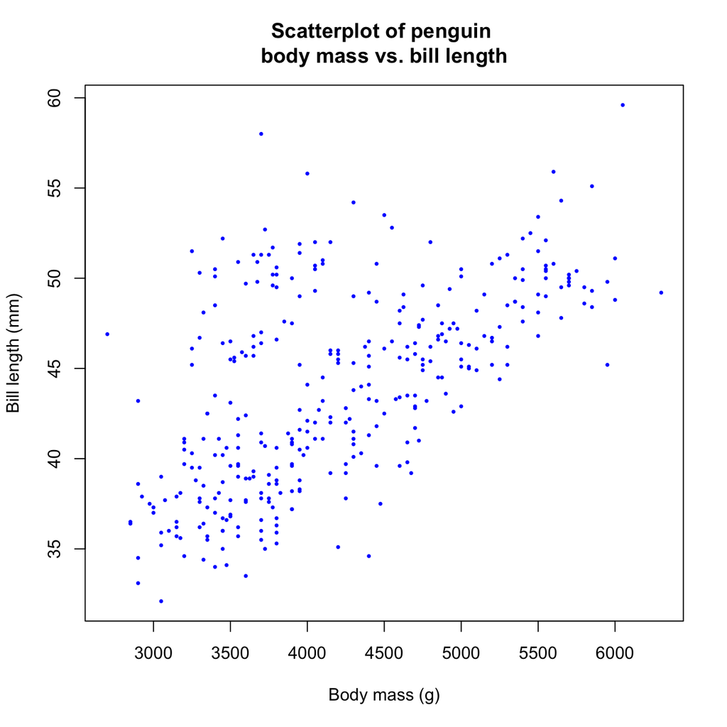

```r
# load the penguins package:
library(palmerpenguins)

plot(bill_length_mm ~ body_mass_g, data = penguins, # Using formula notation
     col = "blue",# col is used to set the color
     pch = 16, # pch is  used to change the symbol
     cex = 0.5, # cex indicates the scaling of plotting text and symbols relative to the default (1)
     main = "Scatterplot of penguin \nbody mass vs. bill length",
     xlab = "Body mass (g)",
     ylab = "Bill length (mm)",
     xlim = c(2700, 6300), ylim = c(32.10, 59.60)) # xlim and ylim are used to set the range on each axis
```

### `hist()`

The function `hist()` creates a histogram of the given data.

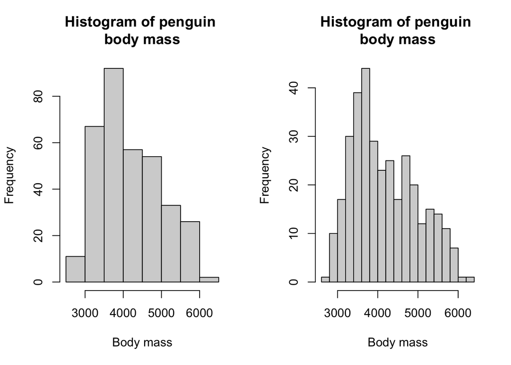

```r
par(mfrow = c(1,2)) # Sets graphical parameters

hist(penguins$body_mass_g, main = "Histogram of penguin \nbody mass", xlab = "Body mass")

# The breaks argument can be used to assign to the histogram a certain number of bins.

hist(penguins$body_mass_g, breaks = 20, main = "Histogram of penguin \nbody mass", xlab = "Body mass")
```

```r
dev.off() # Resets graphical parameters
```

### `boxplot()`

The function `boxplot()` creates a box-and-whisker plot of the given data.

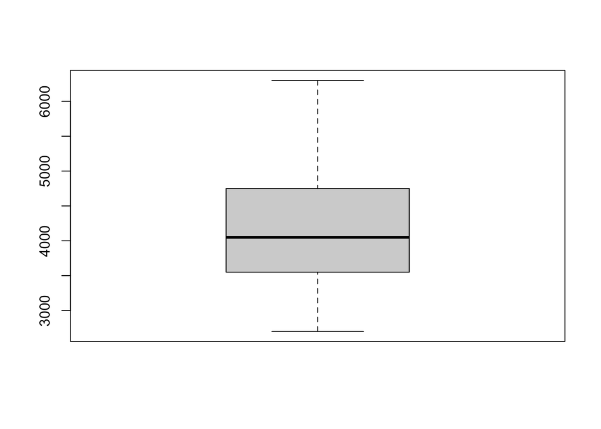

```r
# First we will create a simple boxplot of penguin body mass.
boxplot(penguins$body_mass_g)
```

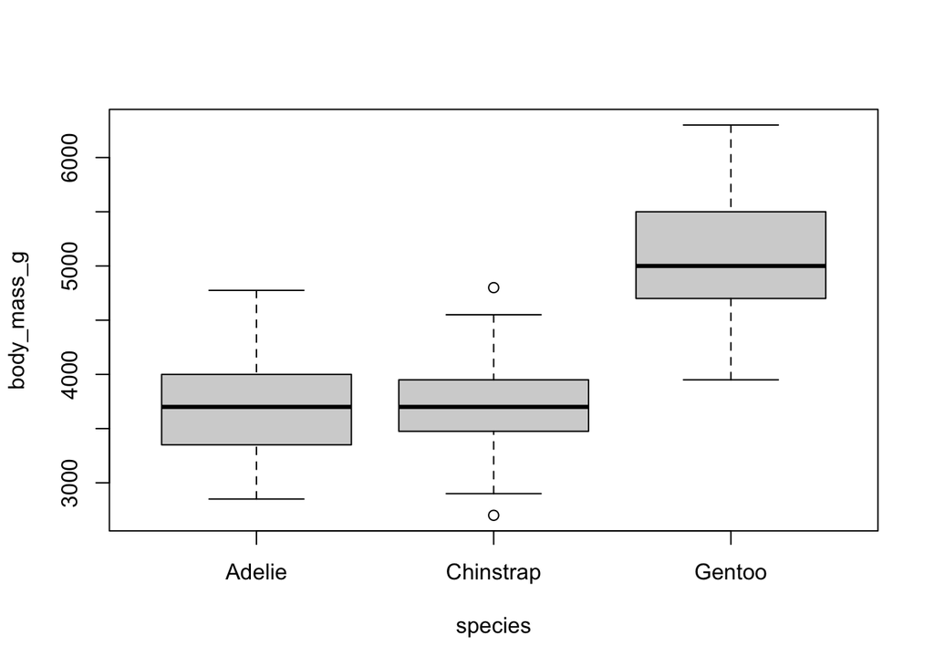

```r
# There seems to be a wide range of body masses. Let's create several boxplots of penguins body mass, conditioned on species.

boxplot(body_mass_g ~ species, data = penguins)
```

```r
# Conditioning data on categorical variables can give lots of insight into our data.
```